# SAVI case study — universal healthy baseline

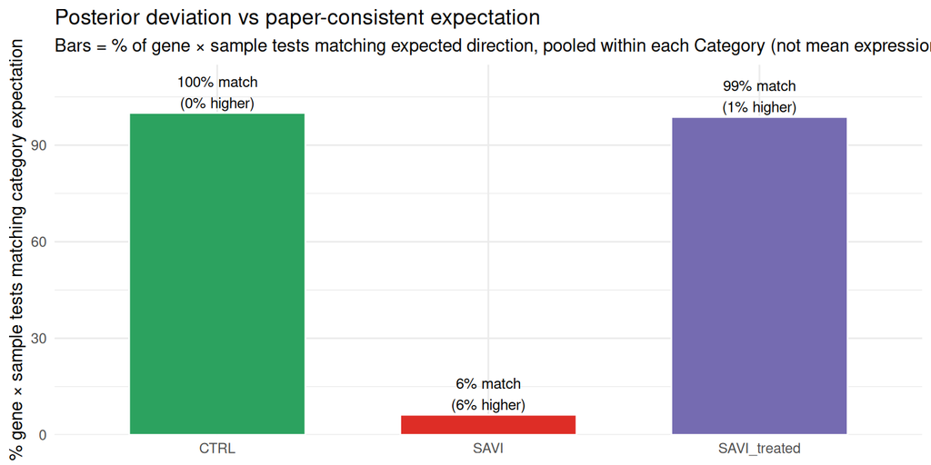

```r
ggplot2::ggplot(
  agreement_by_category,
  ggplot2::aes(
    x = .data$Category,
    y = .data$pct_match,
    fill = .data$Category
  )
) +
  ggplot2::geom_col(width = 0.65, colour = "white") +
  ggplot2::geom_text(
    ggplot2::aes(
      label = sprintf(
        "%.0f%% match\n(%.0f%% higher)",
        .data$pct_match,
        .data$pct_higher
      )
    ),
    vjust = -0.15,
    size = 3.2
  ) +
  ggplot2::scale_fill_manual(values = category_cols) +
  ggplot2::scale_y_continuous(limits = c(0, 115), expand = c(0, 0)) +
  ggplot2::labs(
    x = NULL,
    y = "% gene × sample tests matching category expectation",
    title = "Posterior deviation vs paper-consistent expectation",
    subtitle = "Bars = % of gene × sample tests matching expected direction, pooled within each Category (not mean expression)."
  ) +
  ggplot2::theme_minimal(base_size = 11) +
  ggplot2::theme(legend.position = "none")
```

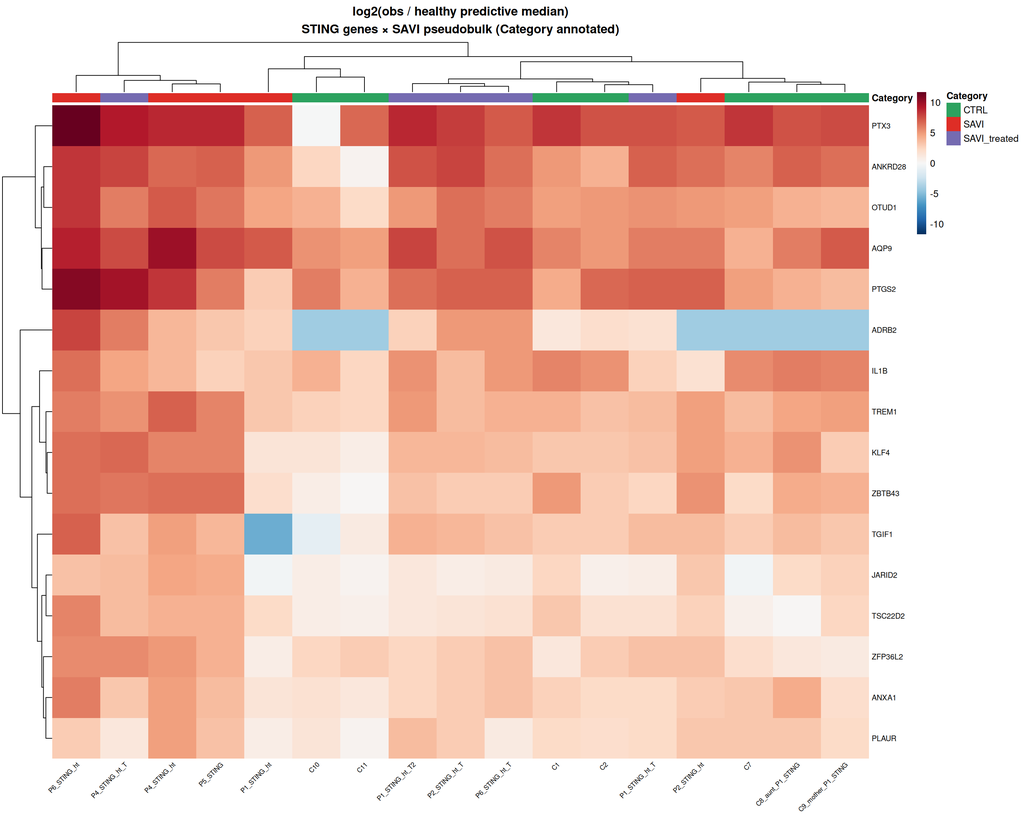

```r
heatmap_df <- gene_deviation_eval |>
  dplyr::filter(!is.na(.data$Category)) |>
  dplyr::mutate(
    Category = factor(.data$Category, levels = names(category_cols))
  )

mat_log2fc <- heatmap_df |>
  dplyr::select("gene", "sample", "log2fc_vs_median") |>
  tidyr::pivot_wider(names_from = "sample", values_from = "log2fc_vs_median") |>
  tibble::column_to_rownames("gene") |>
  as.matrix()

score_mat <- heatmap_df |>
  dplyr::select("gene", "sample", "deviation_score") |>
  tidyr::pivot_wider(names_from = "sample", values_from = "deviation_score") |>
  tibble::column_to_rownames("gene") |>
  as.matrix()

# Category only in annotation_col: pheatmap draws one legend per annotated
# column; adding Sample (~17 levels, no ann_colors) stacks a second legend and
# the "Category" title overlaps the colour keys (see pheatmap issue with multi-legends).
annotation_col <- heatmap_df |>
  dplyr::distinct(.data$sample, .data$Category) |>
  tibble::column_to_rownames("sample") |>
  dplyr::select("Category")

sample_labels <- heatmap_df |>
  dplyr::distinct(.data$sample, .data$Sample) |>
  tibble::deframe()

labels_col <- unname(sample_labels[colnames(mat_log2fc)])

ann_colors <- list(Category = category_cols)

lim_log2 <- max(abs(mat_log2fc), na.rm = TRUE)
if (!is.finite(lim_log2) || lim_log2 == 0) lim_log2 <- 1

pheatmap::pheatmap(
  mat_log2fc,
  annotation_col = annotation_col,
  annotation_colors = ann_colors,
  labels_col = labels_col,
  cluster_rows = TRUE,
  cluster_cols = TRUE,
  clustering_method = "ward.D2",
  color = grDevices::colorRampPalette(rev(RColorBrewer::brewer.pal(11, "RdBu")))(100),
  breaks = seq(-lim_log2, lim_log2, length.out = 101),
  border_color = NA,
  fontsize_row = 8,
  fontsize_col = 7,
  angle_col = 45,
  main = "log2(obs / healthy predictive median)\nSTING genes × SAVI pseudobulk (Category annotated)"
)
```

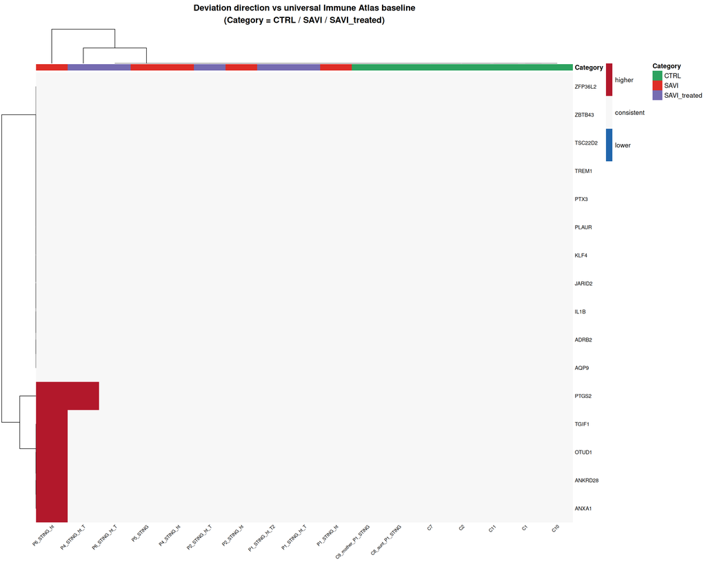

```r
pheatmap::pheatmap(
  score_mat,
  annotation_col = annotation_col,
  annotation_colors = ann_colors,
  labels_col = labels_col,
  cluster_rows = TRUE,
  cluster_cols = TRUE,
  clustering_method = "ward.D2",
  color = grDevices::colorRampPalette(c("#2166ac", "#f7f7f7", "#b2182b"))(3),
  breaks = c(-1.5, -0.5, 0.5, 1.5),
  legend_breaks = c(-1, 0, 1),
  legend_labels = c("lower", "consistent", "higher"),
  border_color = NA,
  fontsize_row = 8,
  fontsize_col = 7,
  angle_col = 45,
  main = "Deviation direction vs universal Immune Atlas baseline\n(Category = CTRL / SAVI / SAVI_treated)"
)
```

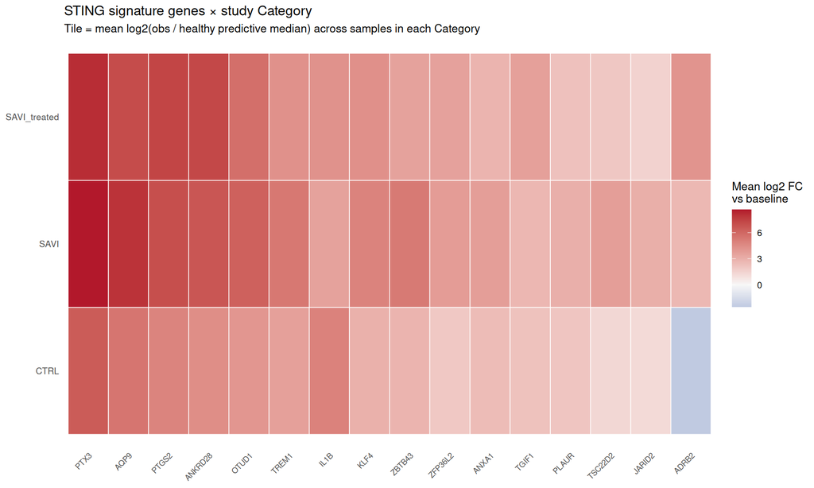

```r
gene_match_summary <- gene_deviation_eval |>
  dplyr::filter(!is.na(.data$Category)) |>
  dplyr::group_by(.data$gene, .data$Category, .data$expected_deviation) |>
  dplyr::summarise(
    n = dplyr::n(),
    pct_higher = 100 * mean(.data$signature_up),
    pct_match = 100 * mean(.data$matches_literature, na.rm = TRUE),
    mean_log2fc = mean(.data$log2fc_vs_median, na.rm = TRUE),
    .groups = "drop"
  ) |>
  dplyr::mutate(
    gene = forcats::fct_reorder(.data$gene, .data$mean_log2fc, .fun = mean, .desc = TRUE)
  )

ggplot2::ggplot(
  gene_match_summary,
  ggplot2::aes(
    x = .data$gene,
    y = .data$Category,
    fill = .data$mean_log2fc
  )
) +
  ggplot2::geom_tile(colour = "white", linewidth = 0.3) +
  ggplot2::scale_fill_gradient2(
    low = "#2166ac",
    mid = "#f7f7f7",
    high = "#b2182b",
    midpoint = 0,
    name = "Mean log2 FC\nvs baseline"
  ) +
  ggplot2::labs(
    x = NULL,
    y = NULL,
    title = "STING signature genes × study Category",
    subtitle = "Tile = mean log2(obs / healthy predictive median) across samples in each Category"
  ) +
  ggplot2::theme_minimal(base_size = 10) +
  ggplot2::theme(
    axis.text.x = ggplot2::element_text(angle = 45, hjust = 1, size = 7),
    panel.grid = ggplot2::element_blank()
  )
```

```r
gene_deviation_eval |>
  dplyr::filter(!is.na(.data$Category)) |>
  dplyr::group_by(.data$Category, .data$gene) |>
  dplyr::summarise(
    n_samples = dplyr::n_distinct(.data$sample),
    n_higher = sum(.data$signature_up),
    pct_higher = 100 * mean(.data$signature_up),
    matches_paper = all(.data$matches_literature %in% TRUE),
    .groups = "drop"
  ) |>
  dplyr::group_by(.data$Category) |>
  dplyr::summarise(
    n_genes_tested = dplyr::n(),
    n_genes_all_higher = sum(.data$n_higher == .data$n_samples),
    n_genes_majority_higher = sum(.data$pct_higher > 50),
    n_genes_paper_perfect = sum(.data$matches_paper),
    .groups = "drop"
  ) |>
  dplyr::left_join(
    agreement_by_category |>
      dplyr::select("Category", "pct_match", "pct_higher"),
    by = "Category"
  )
```

| Category | n_genes_tested | n_genes_all_higher | n_genes_majority_higher | n_genes_paper_perfect | pct_match | pct_higher |
| --- | --- | --- | --- | --- | --- | --- |
| CTRL | 16 | 0 | 0 | 16 | 100.00 | 0.00 |
| SAVI | 16 | 0 | 0 | 0 | 6.25 | 6.25 |
| SAVI_treated | 16 | 0 | 0 | 15 | 98.75 | 1.25 |

# Biomarker quality check (atlas-based falsification)

De Cevins *et al.* (2023) propose the **21-gene signature** by **within-cohort comparison** (5 SAVI vs 7 in-study controls). With only seven matched donors, a gene that is simply **variable in healthy people** but happened to be low in their controls can pass that filter. We can sanity-check each signature gene against a much broader **healthy reference** (Immune Atlas monocytic posteriors), which is the kind of falsification their paper could not do. The expected pattern under a true SAVI biomarker is:

- **SAVI** samples → consistently **higher** than the atlas healthy distribution
- **SAVI_treated** samples → **intermediate** (attenuated by treatment)
- **CTRL** samples → **consistent with healthy** (atlas baseline matches the in-cohort controls)

A gene fails the check (paper-supported but **not** atlas-supported) when:

- **CTRL drifts up** vs atlas (gene is high in many healthy people, not just SAVI),
- **No SAVI lift** vs CTRL (paper effect is within healthy variability),
- **SAVI_treated ≥ SAVI** (no treatment effect even though paper claims one).

```r
biomarker_per_category <- gene_deviation_eval |>
  dplyr::filter(!is.na(.data$Category)) |>
  dplyr::group_by(.data$gene, .data$Category) |>
  dplyr::summarise(
    n_samples = dplyr::n_distinct(.data$sample),
    mean_log2fc = mean(.data$log2fc_vs_median, na.rm = TRUE),
    median_log2fc = stats::median(.data$log2fc_vs_median, na.rm = TRUE),
    pct_higher = 100 * mean(.data$direction == "higher_than_healthy"),
    pct_lower = 100 * mean(.data$direction == "lower_than_healthy"),
    pct_consistent = 100 * mean(.data$direction == "consistent_with_healthy"),
    mean_p_above_healthy = mean(.data$p_above_healthy, na.rm = TRUE),
    .groups = "drop"
  )

biomarker_per_category |>
  dplyr::arrange(.data$gene, .data$Category)
```

| gene | Category | n_samples | mean_log2fc | median_log2fc | pct_higher | pct_lower | pct_consistent | mean_p_above_healthy |
| --- | --- | --- | --- | --- | --- | --- | --- | --- |
| ADRB2 | CTRL | 7 | -2.531148 | -4.1699250 | 0 | 0 | 100 | 0.82420153 |
| ADRB2 | SAVI | 5 | 2.644120 | 3.0556640 | 0 | 0 | 100 | 0.35973571 |
| ADRB2 | SAVI_treated | 5 | 4.151721 | 5.0330260 | 0 | 0 | 100 | 0.19713095 |
| ANKRD28 | CTRL | 7 | 4.436032 | 4.9280692 | 0 | 0 | 100 | 0.14442560 |
| ANKRD28 | SAVI | 5 | 6.699781 | 6.6070380 | 20 | 0 | 80 | 0.04092143 |
| ANKRD28 | SAVI_treated | 5 | 7.249244 | 7.2617382 | 0 | 0 | 100 | 0.03113274 |
| ANXA1 | CTRL | 7 | 2.482442 | 2.1521999 | 0 | 0 | 100 | 0.16403104 |
| ANXA1 | SAVI | 5 | 3.747060 | 3.5498936 | 20 | 0 | 80 | 0.09877679 |
| ANXA1 | SAVI_treated | 5 | 2.818059 | 2.9901224 | 0 | 0 | 100 | 0.12228452 |
| AQP9 | CTRL | 7 | 5.451375 | 5.3661781 | 0 | 0 | 100 | 0.19313903 |

[output cut: 38 more lines]

```r
biomarker_quality <- biomarker_per_category |>
  dplyr::select(
    "gene",
    "Category",
    "mean_log2fc",
    "pct_higher",
    "pct_consistent"
  ) |>
  tidyr::pivot_wider(
    names_from = "Category",
    values_from = c("mean_log2fc", "pct_higher", "pct_consistent"),
    values_fill = NA_real_,
    names_sep = "."
  ) |>
  dplyr::mutate(
    savi_lift = .data$mean_log2fc.SAVI,
    ctrl_drift = .data$mean_log2fc.CTRL,
    treated_lift = .data$mean_log2fc.SAVI_treated,

    # SAVI vs in-cohort controls' atlas-corrected position (paper's main claim).
    savi_vs_ctrl = .data$savi_lift - .data$ctrl_drift,

    # Treatment effect: positive means SAVI_treated drops back toward baseline.
    treatment_attenuation = .data$savi_lift - .data$treated_lift,

    # Atlas baseline agreement of in-study controls (closer to 0 = better).
    abs_ctrl_drift = abs(.data$ctrl_drift),

    # Composite quality: reward SAVI > CTRL, reward treatment drop,
    # penalise CTRL drift from atlas. Weights chosen so all three terms are on
    # the log2 scale; tweak if needed.
    quality_score = .data$savi_vs_ctrl +
      0.5 * .data$treatment_attenuation -
      0.5 * .data$abs_ctrl_drift,

    biomarker_class = dplyr::case_when(
      .data$pct_higher.SAVI >= 60 &
        .data$pct_consistent.CTRL >= 50 &
        .data$treatment_attenuation > 0 ~ "validated",
      .data$pct_higher.SAVI >= 60 &
        .data$treatment_attenuation > 0 &
        .data$pct_consistent.CTRL < 50 ~ "validated_ctrl_drifts",
      .data$pct_higher.SAVI >= 60 &
        .data$treatment_attenuation <= 0 ~ "savi_up_no_treatment_effect",
      .data$pct_higher.SAVI < 30 &
        .data$ctrl_drift > 0.5 ~ "falsified_baseline_high",
      .data$pct_higher.SAVI < 30 ~ "falsified_no_savi_signal",
      TRUE ~ "ambiguous"
    )
  ) |>
  dplyr::arrange(dplyr::desc(.data$quality_score))

biomarker_quality |>
  dplyr::select(
    "gene",
    "biomarker_class",
    "quality_score",
    "savi_vs_ctrl",
    "treatment_attenuation",
    "abs_ctrl_drift",
    dplyr::starts_with("pct_higher."),
    dplyr::starts_with("pct_consistent.")
  )
```

| gene | biomarker_class | quality_score | savi_vs_ctrl | treatment_attenuation | abs_ctrl_drift | pct_higher.CTRL | pct_higher.SAVI | pct_higher.SAVI_treated | pct_consistent.CTRL | pct_consistent.SAVI | pct_consistent.SAVI_treated |
| --- | --- | --- | --- | --- | --- | --- | --- | --- | --- | --- | --- |
| ADRB2 | falsified_no_savi_signal | 3.1558936 | 5.1752683 | -1.5076011 | 2.531148 | 0 | 0 | 0 | 100 | 100 | 100 |
| TSC22D2 | falsified_baseline_high | 2.5928567 | 2.4014497 | 1.7275833 | 1.344769 | 0 | 0 | 0 | 100 | 100 | 100 |
| JARID2 | falsified_baseline_high | 1.9444836 | 1.8106468 | 1.4931962 | 1.225523 | 0 | 0 | 0 | 100 | 100 | 100 |
| ZBTB43 | falsified_baseline_high | 1.9258690 | 2.4785204 | 1.6903939 | 2.795697 | 0 | 0 | 0 | 100 | 100 | 100 |
| ZFP36L2 | falsified_baseline_high | 0.9761253 | 1.8511210 | 0.2098942 | 1.959885 | 0 | 0 | 0 | 100 | 100 | 100 |
| KLF4 | falsified_baseline_high | 0.7363497 | 1.9381389 | 0.5491087 | 2.952687 | 0 | 0 | 0 | 100 | 100 | 100 |
| ANXA1 | falsified_baseline_high | 0.4878984 | 1.2646186 | 0.9290012 | 2.482442 | 0 | 20 | 0 | 100 | 80 | 100 |
| OTUD1 | falsified_baseline_high | 0.4557839 | 2.2099146 | 0.5560805 | 4.064342 | 0 | 20 | 0 | 100 | 80 | 100 |
| TREM1 | falsified_baseline_high | 0.4173874 | 1.7125243 | 1.0560991 | 3.646373 | 0 | 0 | 0 | 100 | 100 | 100 |
| PLAUR | falsified_baseline_high | 0.2345864 | 0.9085628 | 0.7504221 | 2.098375 | 0 | 0 | 0 | 100 | 100 | 100 |

[output cut: 6 more lines]

```r
# Reuse universal-null draws saved in predict-sting-vs-healthy (no second posterior_predict).
if (!exists("gene_baseline_draws", inherits = TRUE)) {
  if (!file.exists(params$gene_baseline_draws_rds)) {
    stop(
      "Missing `gene_baseline_draws`. Run chunk `predict-sting-vs-healthy` first ",
      "(writes ", params$gene_baseline_draws_rds, ")."
    )
  }
  gene_baseline_draws_store <- readRDS(params$gene_baseline_draws_rds)
  gene_baseline_draws <- gene_baseline_draws_as_long(gene_baseline_draws_store)
}

gene_order <- biomarker_quality$gene

biomarker_null_draws <- gene_baseline_draws |>
  dplyr::filter(.data$gene %in% gene_order)

biomarker_obs_points <- gene_deviation_eval |>
  dplyr::filter(.data$gene %in% gene_order) |>
  dplyr::mutate(
    gene = factor(.data$gene, levels = gene_order),
    Category = factor(
      .data$Category,
      levels = c("CTRL", "SAVI_treated", "SAVI")
    ),
    count_label = sprintf("%.3g", .data$observed_scaled)
  )

biomarker_null_draws <- biomarker_null_draws |>
  dplyr::mutate(gene = factor(.data$gene, levels = gene_order))
```

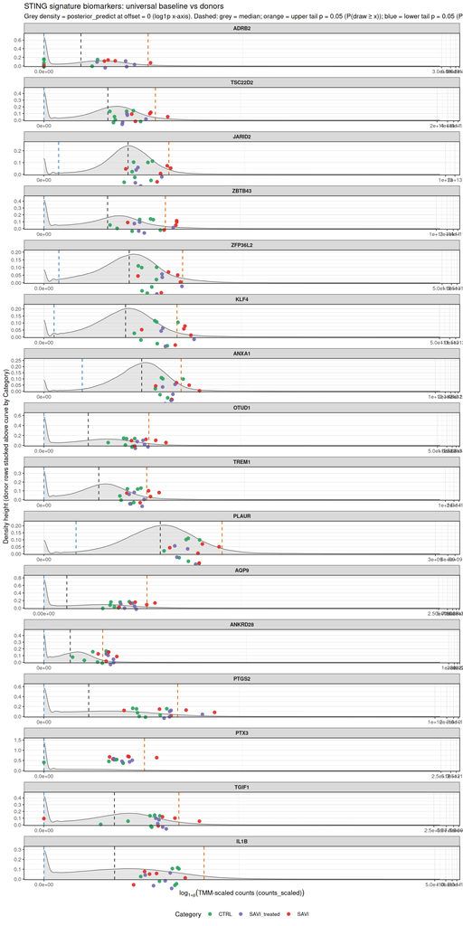

```r
log1p_count_trans <- scales::trans_new(
  name = "log1p",
  transform = function(x) log1p(pmax(x, 0)),
  inverse = function(x) expm1(x),
  domain = c(0, Inf)
)

biomarker_null_median <- biomarker_null_draws |>
  dplyr::group_by(.data$gene) |>
  dplyr::summarise(
    baseline_median = stats::median(.data$counts_scaled, na.rm = TRUE),
    .groups = "drop"
  )

# x where empirical P(draw >= x) = 0.05 and P(draw <= x) = 0.05 (upper / lower tail).
biomarker_null_p05 <- biomarker_null_draws |>
  dplyr::group_by(.data$gene) |>
  dplyr::summarise(
    upper_p05 = stats::quantile(
      .data$counts_scaled,
      probs = 0.95,
      na.rm = TRUE,
      names = FALSE
    ),
    lower_p05 = stats::quantile(
      .data$counts_scaled,
      probs = 0.05,
      na.rm = TRUE,
      names = FALSE
    ),
    .groups = "drop"
  )

category_y_levels <- c(
  CTRL = 1,
  SAVI_treated = 2,
  SAVI = 3
)

# Per-gene max KDE height so donor rows sit above the density (not on y = 1–3).
biomarker_density_max <- biomarker_null_draws |>
  dplyr::group_by(.data$gene) |>
  dplyr::summarise(
    density_max = {
      xx <- .data$counts_scaled[is.finite(.data$counts_scaled)]
      if (length(xx) < 2L) {
        return(NA_real_)
      }
      max(stats::density(xx)$y, na.rm = TRUE)
    },
    .groups = "drop"
  )

biomarker_obs_points_plot <- biomarker_obs_points |>
  dplyr::left_join(biomarker_density_max, by = "gene") |>
  dplyr::mutate(
    cat_idx = unname(category_y_levels[as.character(.data$Category)]),
    y_category = dplyr::if_else(
      is.finite(.data$density_max) & .data$density_max > 0,
      .data$density_max * (1.1 + 0.25 * (.data$cat_idx - 1L)),
      .data$cat_idx
    )
  )

ggplot2::ggplot() +
  ggplot2::geom_density(
    data = biomarker_null_draws,
    ggplot2::aes(x = .data$counts_scaled),
    fill = "grey82",
    colour = "grey35",
    alpha = 0.55,
    linewidth = 0.35,
    na.rm = TRUE
  ) +
  ggplot2::geom_vline(
    data = biomarker_null_median,
    ggplot2::aes(xintercept = .data$baseline_median),
    linetype = "dashed",
    colour = "grey20",
    linewidth = 0.55,
    inherit.aes = FALSE
  ) +
  ggplot2::geom_vline(
    data = biomarker_null_p05,
    ggplot2::aes(xintercept = .data$upper_p05),
    linetype = "dashed",
    colour = "#D95F02",
    linewidth = 0.55,
    inherit.aes = FALSE
  ) +
  ggplot2::geom_vline(
    data = biomarker_null_p05,
    ggplot2::aes(xintercept = .data$lower_p05),
    linetype = "dashed",
    colour = "#377EB8",
    linewidth = 0.55,
    inherit.aes = FALSE
  ) +
  ggplot2::geom_point(
    data = biomarker_obs_points_plot,
    ggplot2::aes(
      x = .data$observed_scaled,
      y = .data$y_category,
      colour = .data$Category
    ),
    position = ggplot2::position_jitter(width = 0, height = 0.12, seed = 1L),
    size = 2.2,
    alpha = 0.9,
    stroke = 0.35
  ) +
  # ggplot2::geom_text(
  #   data = biomarker_obs_points,
  #   ggplot2::aes(
  #     x = .data$observed_scaled,
  #     y = 0,
  #     label = .data$count_label,
  #     colour = .data$Category
  #   ),
  #   size = 1.85,
  #   hjust = -0.15,
  #   show.legend = FALSE
  # ) +
  ggplot2::facet_wrap(
    ~gene,
    scales = "free",
    ncol = 1,
    labeller = ggplot2::label_wrap_gen(20)
  ) +
  ggplot2::scale_colour_manual(values = category_cols, name = "Category") +
  ggplot2::scale_x_continuous(trans = log1p_count_trans) +
  ggplot2::scale_y_continuous(
    expand = ggplot2::expansion(mult = c(0.02, 0.14))
  ) +
  ggplot2::coord_cartesian(ylim = c(0, NA), clip = "off") +
  # ggplot2::scale_x_continuous(
  #   breaks = NULL,
  #   labels = NULL,
  #   expand = ggplot2::expansion(mult = c(0.12, 0.22))
  # ) +
  ggplot2::labs(
    x = expression(log[1 + p]("TMM-scaled counts (counts_scaled)")),
    y = "Density height (donor rows stacked above curve by Category)",
    title = "STING signature biomarkers: universal baseline vs donors",
    subtitle = paste(
      "Grey density = posterior_predict at offset = 0 (log1p x-axis).",
      "Dashed: grey = median; orange = upper tail p = 0.05 (P(draw \u2265 x));",
      "blue = lower tail p = 0.05 (P(draw \u2264 x))."
    )
  ) +
  ggplot2::theme_bw(base_size = 10) +
  ggplot2::theme(
    legend.position = "bottom",
    strip.text = ggplot2::element_text(size = 8, face = "bold"),
    panel.spacing = grid::unit(0.3, "lines")
  )
```

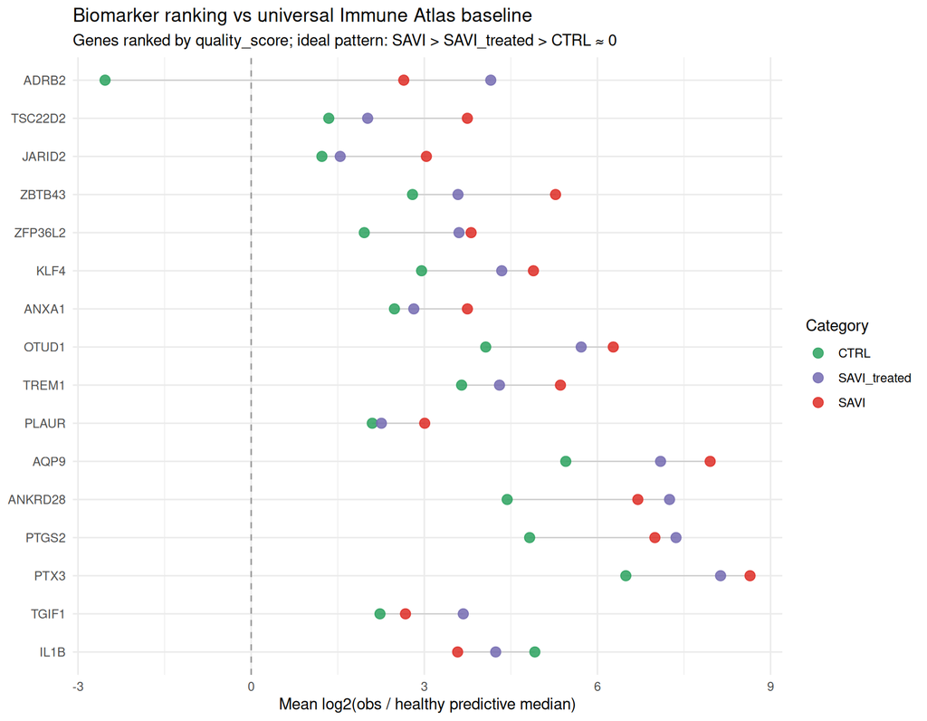

```r
biomarker_long <- biomarker_per_category |>
  dplyr::filter(.data$gene %in% gene_order) |>
  dplyr::mutate(
    gene = factor(.data$gene, levels = rev(gene_order)),
    Category = factor(
      .data$Category,
      levels = c("CTRL", "SAVI_treated", "SAVI")
    )
  )

ggplot2::ggplot(
  biomarker_long,
  ggplot2::aes(
    x = .data$mean_log2fc,
    y = .data$gene,
    colour = .data$Category
  )
) +
  ggplot2::geom_vline(xintercept = 0, linetype = 2, colour = "grey60") +
  ggplot2::geom_line(
    ggplot2::aes(group = .data$gene),
    colour = "grey80",
    linewidth = 0.4
  ) +
  ggplot2::geom_point(size = 3, alpha = 0.85) +
  ggplot2::scale_colour_manual(values = category_cols) +
  ggplot2::labs(
    x = "Mean log2(obs / healthy predictive median)",
    y = NULL,
    title = "Biomarker ranking vs universal Immune Atlas baseline",
    subtitle = "Genes ranked by quality_score; ideal pattern: SAVI > SAVI_treated > CTRL ≈ 0"
  ) +
  ggplot2::theme_minimal(base_size = 11)
```

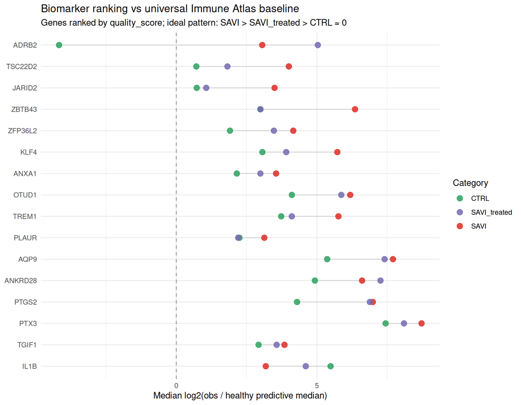

```r
ggplot2::ggplot(
  biomarker_long,
  ggplot2::aes(
    x = .data$median_log2fc,
    y = .data$gene,
    colour = .data$Category
  )
) +
  ggplot2::geom_vline(xintercept = 0, linetype = 2, colour = "grey60") +
  ggplot2::geom_line(
    ggplot2::aes(group = .data$gene),
    colour = "grey80",
    linewidth = 0.4
  ) +
  ggplot2::geom_point(size = 3, alpha = 0.85) +
  ggplot2::scale_colour_manual(values = category_cols) +
  ggplot2::labs(
    x = "Median log2(obs / healthy predictive median)",
    y = NULL,
    title = "Biomarker ranking vs universal Immune Atlas baseline",
    subtitle = "Genes ranked by quality_score; ideal pattern: SAVI > SAVI_treated > CTRL ≈ 0"
  ) +
  ggplot2::theme_minimal(base_size = 11)
```

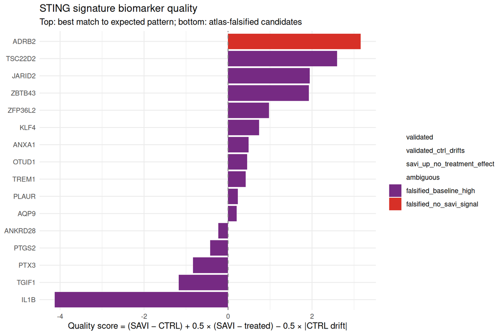

```r
class_levels <- c(
  "validated",
  "validated_ctrl_drifts",
  "savi_up_no_treatment_effect",
  "ambiguous",
  "falsified_baseline_high",
  "falsified_no_savi_signal"
)

class_cols <- c(
  validated = "#1a9850",
  validated_ctrl_drifts = "#66bd63",
  savi_up_no_treatment_effect = "#fee08b",
  ambiguous = "#bdbdbd",
  falsified_baseline_high = "#762a83",
  falsified_no_savi_signal = "#d73027"
)

ggplot2::ggplot(
  biomarker_quality |>
    dplyr::mutate(
      gene = factor(.data$gene, levels = rev(gene_order)),
      biomarker_class = factor(
        .data$biomarker_class,
        levels = class_levels
      )
    ),
  ggplot2::aes(
    x = .data$quality_score,
    y = .data$gene,
    fill = .data$biomarker_class
  )
) +
  ggplot2::geom_col() +
  ggplot2::geom_vline(xintercept = 0, linetype = 2, colour = "grey50") +
  ggplot2::scale_fill_manual(values = class_cols, drop = FALSE) +
  ggplot2::labs(
    x = "Quality score = (SAVI − CTRL) + 0.5 × (SAVI − treated) − 0.5 × |CTRL drift|",
    y = NULL,
    title = "STING signature biomarker quality",
    subtitle = "Top: best match to expected pattern; bottom: atlas-falsified candidates",
    fill = NULL
  ) +
  ggplot2::theme_minimal(base_size = 11) +
  ggplot2::theme(legend.position = "right")
```

```r
biomarker_quality |>
  dplyr::count(.data$biomarker_class, name = "n_genes") |>
  dplyr::arrange(dplyr::desc(.data$n_genes))
```

| biomarker_class | n_genes |
| --- | --- |
| falsified_baseline_high | 15 |
| falsified_no_savi_signal | 1 |

```r
biomarker_quality |>
  dplyr::filter(.data$biomarker_class %in% c(
    "falsified_no_savi_signal",
    "falsified_baseline_high",
    "savi_up_no_treatment_effect"
  )) |>
  dplyr::select(
    "gene",
    "biomarker_class",
    "savi_lift",
    "ctrl_drift",
    "treated_lift",
    "pct_higher.SAVI",
    "pct_higher.CTRL",
    "pct_consistent.CTRL"
  ) |>
  dplyr::arrange(.data$biomarker_class, .data$gene)
```

| gene | biomarker_class | savi_lift | ctrl_drift | treated_lift | pct_higher.SAVI | pct_higher.CTRL | pct_consistent.CTRL |
| --- | --- | --- | --- | --- | --- | --- | --- |
| ANKRD28 | falsified_baseline_high | 6.699781 | 4.436032 | 7.249244 | 20 | 0 | 100 |
| ANXA1 | falsified_baseline_high | 3.747060 | 2.482442 | 2.818059 | 20 | 0 | 100 |
| AQP9 | falsified_baseline_high | 7.953028 | 5.451375 | 7.093395 | 0 | 0 | 100 |
| IL1B | falsified_baseline_high | 3.577469 | 4.915641 | 4.237032 | 0 | 0 | 100 |
| JARID2 | falsified_baseline_high | 3.036170 | 1.225523 | 1.542973 | 0 | 0 | 100 |
| KLF4 | falsified_baseline_high | 4.890826 | 2.952687 | 4.341717 | 0 | 0 | 100 |
| OTUD1 | falsified_baseline_high | 6.274256 | 4.064342 | 5.718176 | 20 | 0 | 100 |
| PLAUR | falsified_baseline_high | 3.006938 | 2.098375 | 2.256516 | 0 | 0 | 100 |
| PTGS2 | falsified_baseline_high | 6.995356 | 4.824918 | 7.361306 | 20 | 0 | 100 |
| PTX3 | falsified_baseline_high | 8.643935 | 6.491738 | 8.133569 | 0 | 0 | 100 |

[output cut: 6 more lines]

**Interpretation:**

- **`validated`** — gene behaves as the paper claims and is **also** consistent with the atlas (high in SAVI, attenuated by treatment, in-cohort controls match atlas baseline). Strong biomarker.
- **`validated_ctrl_drifts`** — gene goes up in SAVI and drops with treatment, but the paper’s controls are already above the atlas baseline. The within-cohort effect is real; absolute reference value should be interpreted with care.
- **`savi_up_no_treatment_effect`** — SAVI lift exists but treatment doesn’t move it. The gene may be a state marker rather than an activity readout.
- **`ambiguous`** — borderline; needs more samples.
- **`falsified_baseline_high`** — gene reads as high in study controls *and* in the broader atlas, and SAVI doesn’t add much on top. The paper’s “up in SAVI” is likely a baseline artefact.
- **`falsified_no_savi_signal`** — no SAVI lift vs atlas at all. Strong falsification candidate.

This is the kind of cross-study check the original paper could not perform because of the small healthy-cohort size.